# 중국 히든젬 스크리닝 보고서 — Week 20

Alpha Hunter Hidden Gem Week 20 — 이번 주 조건 충족 종목 없음 (SEPA + 펀더멘탈 동시 통과 0건)

Author

Alpha Hunter × Chimera AI

Published

May 15, 2026

# 스크리닝 결론

**이번 주 중국 히든젬: 조건 충족 종목 없음**

yfinance 기반 정량 스크리닝 결과, 홍콩/중국ADR 중 **SEPA 트렌드 템플릿 전 조건 + 펀더멘탈 필터**를 동시에 통과하는 종목이 없습니다. Alpha Hunter는 조건을 완화하여 억지로 종목을 선정하지 않습니다.

[output not shown]

# 1 스크리닝 프로세스

## 1.1 STEP 1: 유니버스 구성

중국 ADR (NASDAQ/NYSE) + 홍콩 주요 상장 40+ 종목을 대상으로 yfinance 데이터를 수집했습니다.

**섹터별 커버리지:**

- 전기차(EV): NIO, XPEV, LI
- 반도체: SIMO (기추천), GCT
- 바이오/헬스케어: LEGN, ZLAB, BGNE
- 핀테크: FUTU (기추천), TIGR, QFIN, FINV
- 소비재: MNSO, YUMC, LKNCY, VIPS
- 테크/클라우드: KC, BILI, TME, BEKE
- 교육: TAL, EDU, GOTU
- 기타: ZTO, YMM, WB, VNET

## 1.2 STEP 2: 정량 필터 결과

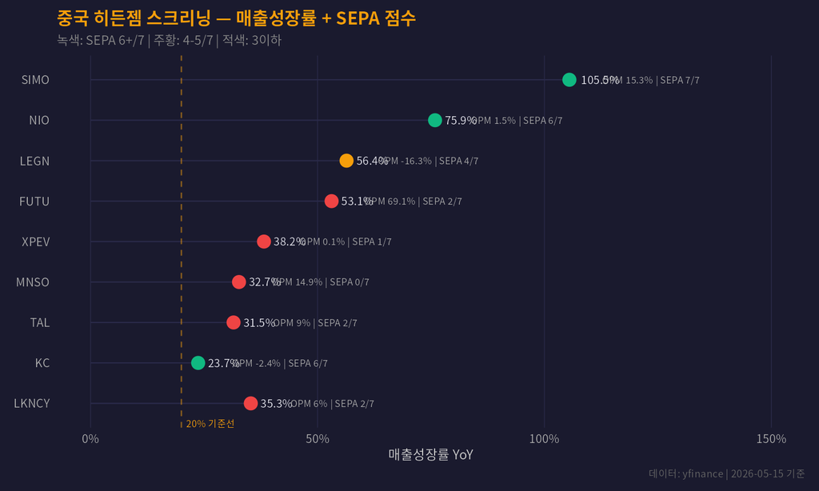

## 1.3 STEP 3: SEPA 트렌드 템플릿 상세

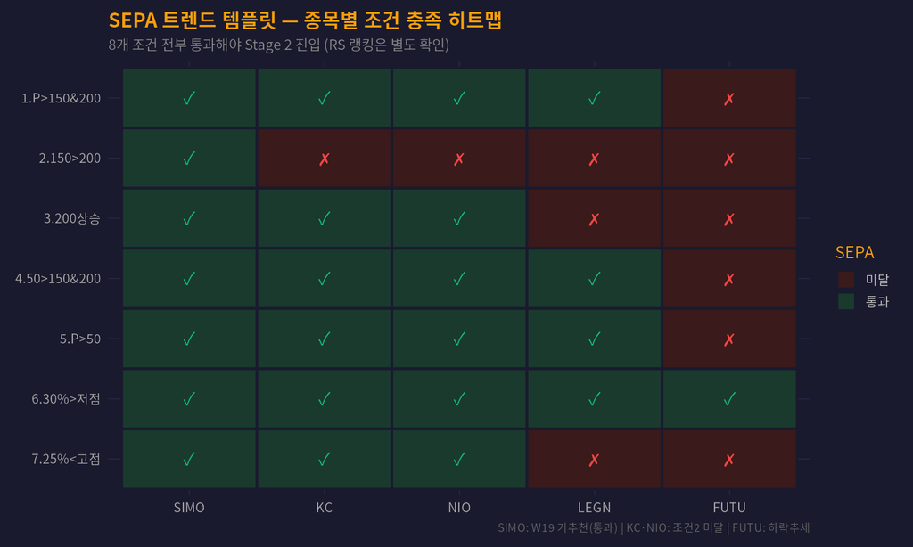

**핵심 발견**

# 2 가장 근접한 후보: KC (Kingsoft Cloud)

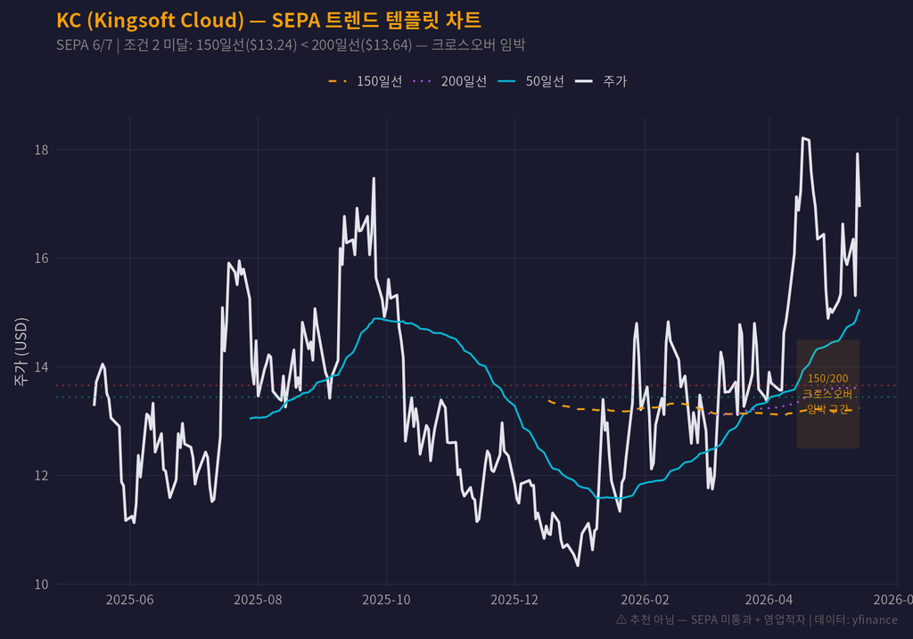

| 항목 | KC (Kingsoft Cloud) |
| --- | --- |
| **티커** | KC (NASDAQ) |
| **업종** | 클라우드 컴퓨팅 / AI 인프라 |
| **시총** | $5.1B |
| **매출성장** | +23.7% YoY |
| **영업이익률** | -2.4% (적자 축소 중) |
| **ROE** | -12.7% |
| **SEPA 점수** | 6/7 (조건2 미달) |
| **미통과 사유** | 150SMA < 200SMA + 영업적자 |
| **모니터링 포인트** | 150/200일선 골든크로스 임박 ($0.40 차이) |

**KC 미추천 사유**

1. **SEPA 조건 2 미달**: 150일선($13.24) < 200일선($13.64). 다만 갭이 $0.40으로 매우 좁아 1~2주 내 크로스오버 가능성 있음.
2. **영업적자**: OPM -2.4%. 클라우드 인프라 투자로 적자이나, 전년 대비 개선 추세.
3. **ROE 음수**: -12.7%. 흑자 전환 전까지 투자 부적합.
4. 향후 흑자 전환 + SEPA 크로스오버 확인 시 재검토 대상.

# 3 중국 산업 트렌드 분석

## 3.1 전기차 (EV)

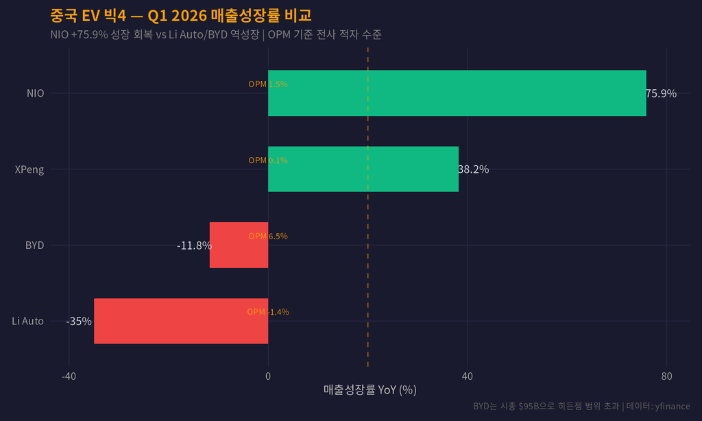

**EV 트렌드 요약:**

- **NIO**: 4월 딜리버리 29,356대 (+22.8% YoY). ONVO 브랜드 확장으로 매출 +75.9% 급성장. 하지만 **ROE -118.7%**, 누적 적자 지속. 5/21 Q1 실적발표 예정.
- **XPeng**: Mona M03 성공으로 판매 급증. 매출 +38.2%. 하지만 OPM 0.1%로 겨우 손익분기.
- **Li Auto**: 경쟁 심화로 역성장 -35%. MEGA 모델 부진.
- 중국 EV 시장은 가격 전쟁 지속. **마진 없는 성장**이 핵심 리스크.

## 3.2 반도체

[figure not shown]

**반도체 트렌드:**

- **미중 반도체 갈등 심화**: 2025~2026 미국의 대중 수출 통제 확대. NVIDIA H20 중국 판매 제한, ASML DUV 장비 규제.
- **중국 국산화 가속**: SMIC 7nm 양산, Huawei HiSilicon 자체 설계 확대. 하지만 EUV 없이는 5nm 이하 불가.
- **SIMO (W19 추천)**: NAND 컨트롤러 1위로 미중 양쪽 수혜. 대만 R&D + 미국 상장으로 지정학 리스크 상대적 경감.
- HBM/AI 반도체 수요 폭발이지만, 중국 기업이 직접 수혜받는 상장종목은 제한적.

## 3.3 바이오/헬스케어

- **LEGN (Legend Biotech)**: CAR-T 치료제 Carvykti 매출 +56.4%. J&J 파트너십. 하지만 여전히 영업적자 (-16.3%), SEPA 4/7.
- **ZLAB (Zai Lab)**: 중국 바이오텍 라이선스 인모델. 매출 +17%. 적자 지속.
- 중국 바이오는 FDA 승인 파이프라인 기반 성장 중이나, **높은 R&D 비용으로 대부분 적자 상태**.

# 4 정치 리스크 대시보드

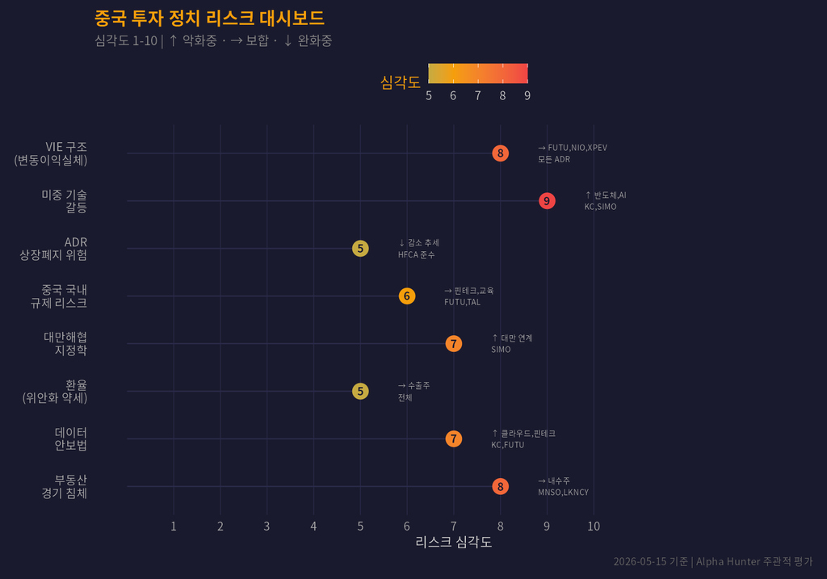

## 4.1 VIE 구조 리스크

**변동이익실체(VIE)**: 대부분 중국 ADR은 실제 중국 사업체가 아닌 케이맨 제도 법인의 주식을 매수하는 구조입니다.

- FUTU, NIO, XPEV, KC 등 주요 중국 ADR은 **VIE 구조**를 통해 상장
- 중국 정부가 VIE를 무효화할 경우 주주 권리 소멸 위험
- 2026년 현재 VIE 무효화 가능성은 낮으나, 미중 관계 악화 시 리스크 재부각 가능

## 4.2 미중 갈등 현황

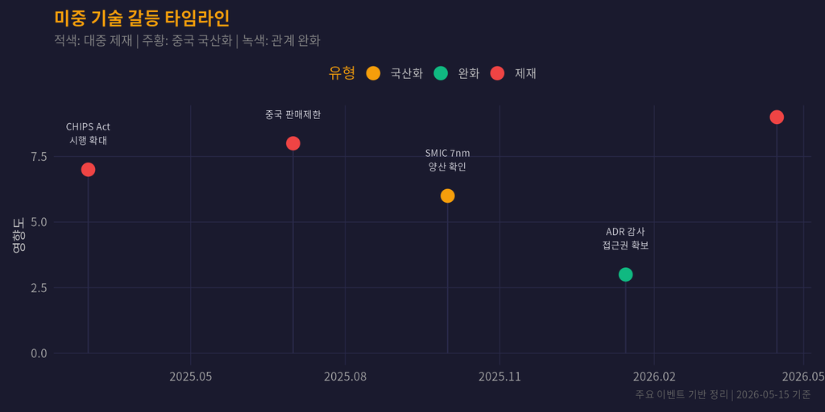

**2026년 미중 상황:**

- **관세**: 2026년 4월 미국 대중 관세 145% 부과 → 90일 유예 → 협상 진행 중. 불확실성 최고조.
- **반도체 제재**: AI 칩 수출 통제 확대. 중국 AI 인프라 성장에 제동.
- **ADR 감사**: HFCA 준수로 상장폐지 리스크는 감소했으나, 완전 해소 아님.
- **데이터 안보법**: 중국 데이터의 해외 이전 규제 강화. 클라우드(KC), 핀테크(FUTU) 직접 영향.

# 5 기존 워치리스트 업데이트

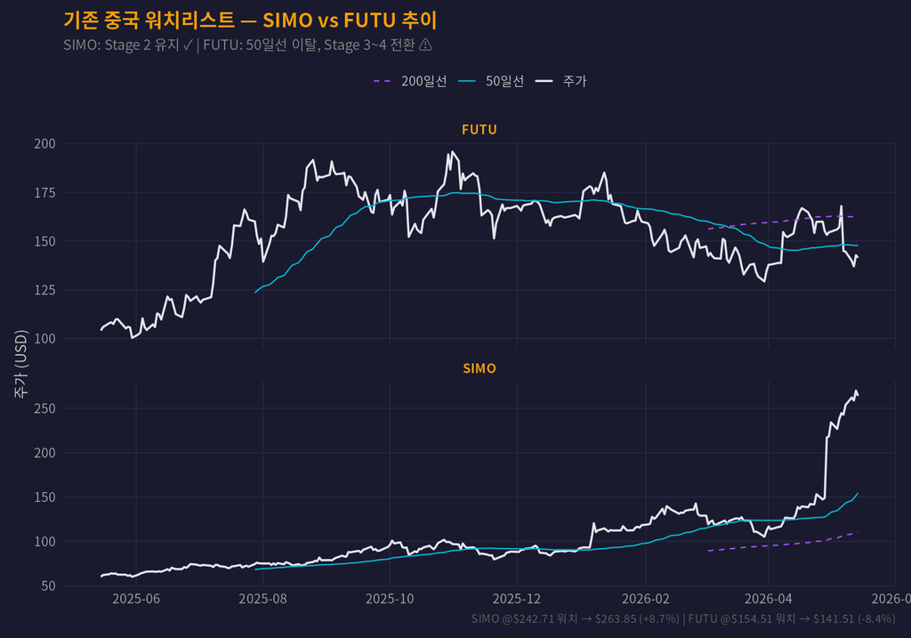

[output not shown]

**FUTU 경고**

# 6 이번 주 미통과 요약

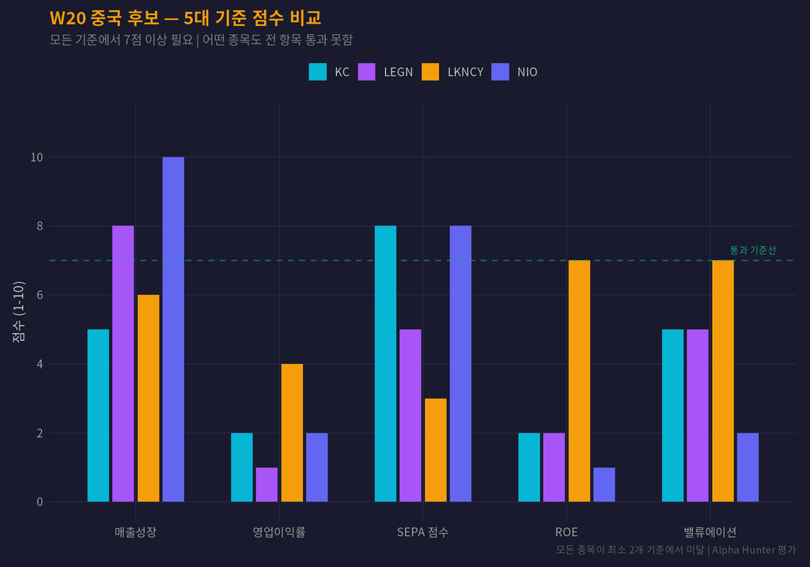

# 7 다음 주 모니터링 포인트

1. **KC (Kingsoft Cloud)**: 150일선/200일선 크로스오버 여부 확인. 흑자 전환 시 재검토.
2. **NIO Q1 실적** (5/21): 마진 개선 여부가 핵심. OPM 5%+ 달성 시 관심 상향.
3. **SIMO**: W19 워치리스트 유지. Q2 가이던스 $393~$411M 달성 여부.
4. **FUTU**: 하락추세 지속 시 워치리스트 제거 검토 (손절가 $120).
5. **미중 관세 협상**: 90일 유예 기간(~7월) 내 합의 가능성. 중국 ADR 전반에 영향.

# 면책 문구

**Note**

이 프로젝트는 가상 투자 시뮬레이션 목적으로 작성되었습니다. 실제 투자 권유가 아닙니다. 모든 투자 결정은 개인의 판단과 책임 하에 이루어져야 합니다.

*Alpha Hunter × Chimera AI | Week 20 China Screening Report | 2026-05-15*